# FinalProject

Abia-Mbu Amberetu

May 16, 2018

### CMSC320 Final Project

Author: Abia-Mbu Amberetu

#### Introduction

https://www.kaggle.com/daverosenman/nba-finals-team-stats Information on NBA finals from 1980 to 2017.

#### Load the libraries needed

1. tidyverse
2. dplyr
3. ggplot2
4. stats
5. stringr

```r
library(tidyverse)
library(dplyr)
library(ggplot2)
library(stringr)
```

# Data Collection and Processing

```r
champ_tab <- read_csv("championsdata.csv")
champ_tab
```

```
## # A tibble: 216 x 25
##    X      Year Team   Game   Win  Home    MP    FG   FGA   FGP    TP   TPA
##    <chr> <int> <chr> <int> <int> <int> <int> <int> <int> <dbl> <int> <int>
##  1 1      1980 Lake~     1     1     1   240    48    89 0.539     0     0
##  2 2      1980 Lake~     2     0     1   240    48    95 0.505     0     1
##  3 3      1980 Lake~     3     1     0   240    44    92 0.478     0     1
##  4 4      1980 Lake~     4     0     0   240    44    93 0.473     0     0
##  5 5      1980 Lake~     5     1     1   240    41    91 0.451     0     0
##  6 6      1980 Lake~     6     1     0   240    45    92 0.489     0     2
##  7 7      1981 Celt~     1     1     1   240    41    95 0.432     0     1
##  8 8      1981 Celt~     2     0     1   240    41    82 0.500     0     3
##  9 9      1981 Celt~     3     1     0   240    40    89 0.449     2     3
## 10 10     1981 Celt~     4     0     0   240    35    74 0.473     0     3
## # ... with 206 more rows, and 13 more variables: TPP <dbl>, FT <int>,
## #   FTA <int>, FTP <dbl>, ORB <int>, DRB <int>, TRB <int>, AST <int>,
## #   STL <int>, BLK <int>, TOV <int>, PF <int>, PTS <int>
```

For this dataset, we have game stats on every game played in the NBA finals since 1980, but only the winning team. We must tidy the data.

```r
champions <-champ_tab %>% group_by(Year,Team) %>%
      summarise(avg_fg= mean(FGP),avg_fta= mean(FTA), avg_ftp= mean(FTP), wins= sum(Win),            avg_reb= mean(TRB), avg_assists= mean(AST), avg_steals= mean(STL), avg_blocks= mean(BLK), avg_pts= mean(PTS)) %>% mutate(Champs=ifelse(wins ==4, 1,0)) %>% filter(wins ==4)
champions
```

```
## # A tibble: 38 x 12
## # Groups:   Year [38]
##     Year Team  avg_fg avg_fta avg_ftp  wins avg_reb avg_assists avg_steals
##    <int> <chr>  <dbl>   <dbl>   <dbl> <int>   <dbl>       <dbl>      <dbl>
##  1  1980 Lake~  0.489    24.0   0.795     4    51.3        26.7       9.17
##  2  1981 Celt~  0.474    21.5   0.720     4    47.3        22.8       6.67
##  3  1982 Lake~  0.495    31.5   0.669     4    47.3        31.3      10.7
##  4  1983 Sixe~  0.487    34.5   0.709     4    48.0        26.0      11.0
##  5  1984 Celt~  0.454    38.6   0.797     4    47.4        24.1       9.86
##  6  1985 Lake~  0.512    29.7   0.733     4    42.7        32.0       9.17
##  7  1986 Celt~  0.494    23.0   0.809     4    45.2        28.0       9.83
##  8  1987 Lake~  0.514    25.8   0.747     4    40.3        26.7       8.00
##  9  1988 Lake~  0.468    35.3   0.749     4    37.6        23.7       5.86
## 10  1989 Pist~  0.525    31.2   0.799     4    40.0        24.2       4.00
## # ... with 28 more rows, and 3 more variables: avg_blocks <dbl>,
## #   avg_pts <dbl>, Champs <dbl>
```

The package being utilized here is “dplyr” which allows us to run our dataset through a pipeline of functions using(%>%). 1. We group the data by Year and team using group_by() 2. We summarise the data, creating new attributs(avg_reb,avg_assists,etc). 3. I had to do a bit of Tidying for this dataset. 2 of the years were duplicated and I noticed that the Team names were spelled incorrectly. I also noticed the amount of wins is 0 for these incorrect years.So i called a filter funtion that removes any entity that doesnt have 4 wins(which is how much wins a championship team has)

```r
runnerups <- read.csv("runnerupsdata.csv")
runner_ups <- runnerups %>% group_by(Year,Team) %>%
      summarise(avg_fg= mean(FGP),avg_fta= mean(FTA), avg_ftp= mean(FTP),
      wins=sum(Win),avg_reb= mean(TRB), avg_assists= mean(AST), avg_steals= mean(STL),               avg_blocks=mean(BLK),avg_pts= mean(PTS)) %>% mutate(Champs=ifelse(wins ==4, 1,0))

runner_ups
```

```
## # A tibble: 38 x 12
## # Groups:   Year [38]
##     Year Team  avg_fg avg_fta avg_ftp  wins avg_reb avg_assists avg_steals
##    <int> <fct>  <dbl>   <dbl>   <dbl> <int>   <dbl>       <dbl>      <dbl>
##  1  1980 Sixe~  0.488    24.0   0.737     2    37.2        31.0       9.33
##  2  1981 Rock~  0.377    25.8   0.729     2    42.7        18.0       7.83
##  3  1982 Sixe~  0.498    27.8   0.694     2    41.7        28.7       8.83
##  4  1983 Lake~  0.451    23.2   0.744     0    42.8        24.5       9.00
##  5  1984 Lake~  0.516    32.9   0.706     2    43.7        28.3       8.43
##  6  1985 Celt~  0.474    30.3   0.764     2    43.2        30.8       8.67
##  7  1986 Rock~  0.450    24.7   0.701     2    45.5        27.5       9.00
##  8  1987 Celt~  0.505    27.0   0.790     2    41.3        27.8       5.00
##  9  1988 Pist~  0.479    29.7   0.776     3    43.6        23.3       6.86
## 10  1989 Lake~  0.465    36.0   0.752     0    36.2        23.0       5.50
## # ... with 28 more rows, and 3 more variables: avg_blocks <dbl>,
## #   avg_pts <dbl>, Champs <dbl>
```

# Visualization and Exploratory Data Analysis

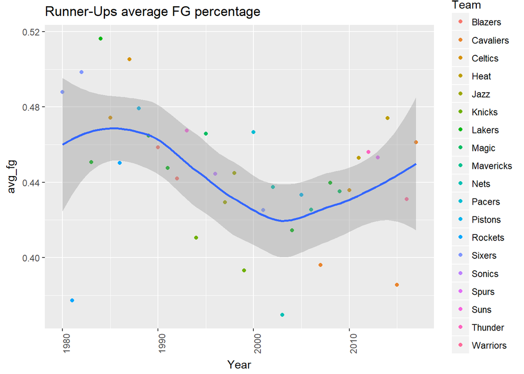

```r
#records <- read.csv("Team_Records.csv")
#records$year <- gsub("^(\\d{4}).*", '\\1',records$ï..Season)

#Plot for Runner-Ups average FG Percentage for every year in the dataset
runner_ups %>%
  ggplot(mapping=aes(x=Year, y=avg_fg,label= Team)) +
  theme(axis.text.x = element_text(angle = 90, hjust = 1))+
  geom_point(aes(color= Team)) + geom_smooth() + ggtitle("Runner-Ups average FG percentage")
```

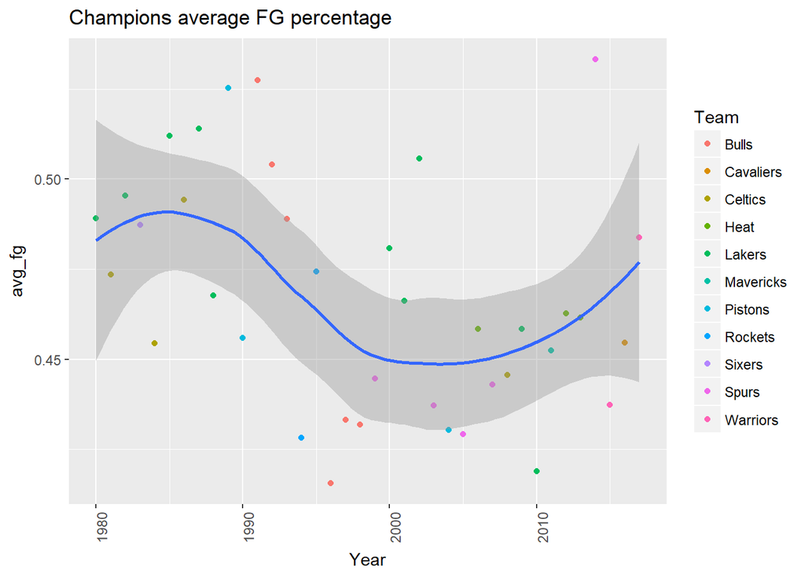

```r
#Plot for Champions average FG Percentage for every year in the dataset
champions %>% ggplot(mapping=aes(x=Year, y=avg_fg,label= Team)) +
  theme(axis.text.x = element_text(angle = 90, hjust = 1))+
  geom_point(aes(color= Team)) + geom_smooth() + ggtitle("Champions average FG percentage")
```

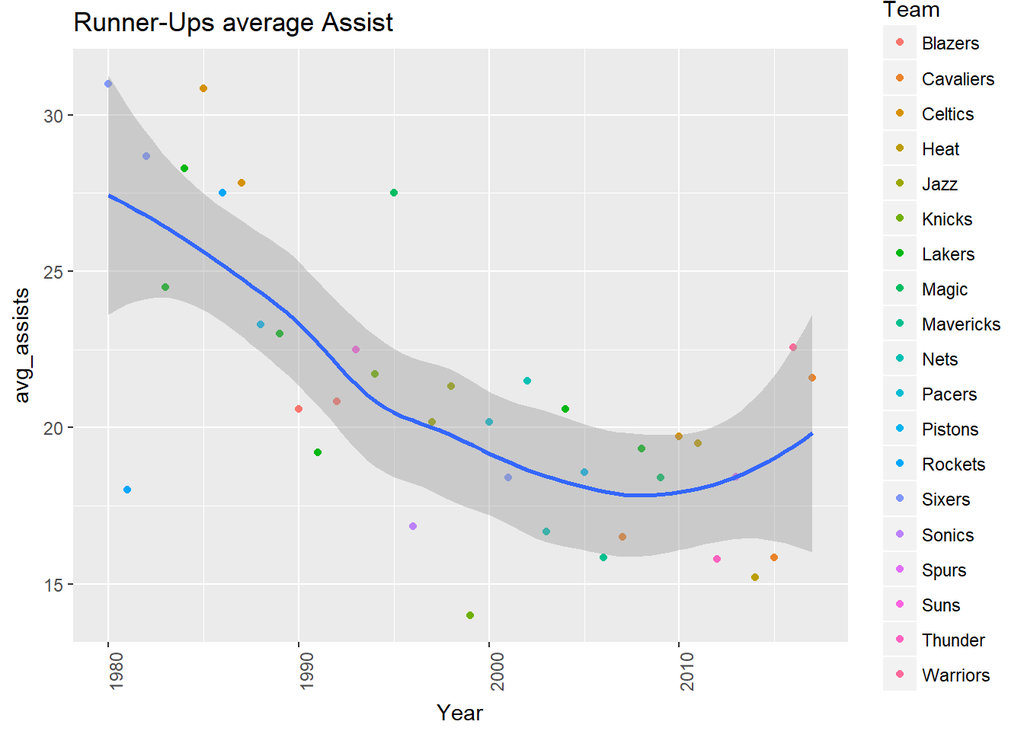

```r
#Plot for Runner-Ups average Assists every year in the data set
runner_ups %>%
   ggplot(mapping=aes(x=Year, y=avg_assists,label= Team)) +
  theme(axis.text.x = element_text(angle = 90, hjust = 1))+
  geom_point(aes(color= Team)) + geom_smooth() + ggtitle("Runner-Ups average Assist")
```

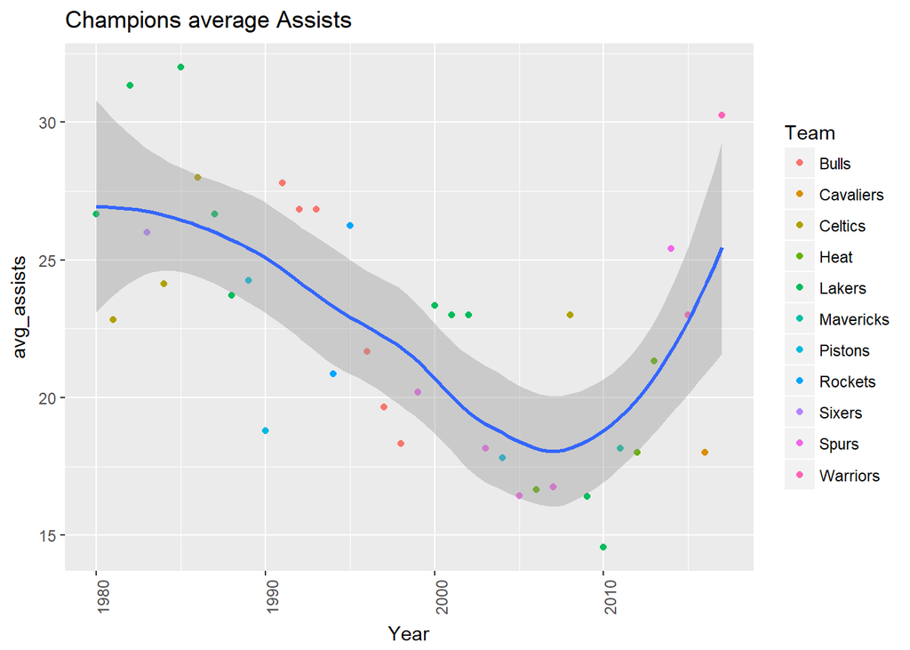

```r
#Plot for Champions average Assists every year in the data set
champions %>%ggplot(mapping=aes(x=Year, y=avg_assists,label= Team)) +
  theme(axis.text.x = element_text(angle = 90, hjust = 1))+
  geom_point(aes(color= Team)) + geom_smooth() + ggtitle("Champions average Assists")
```

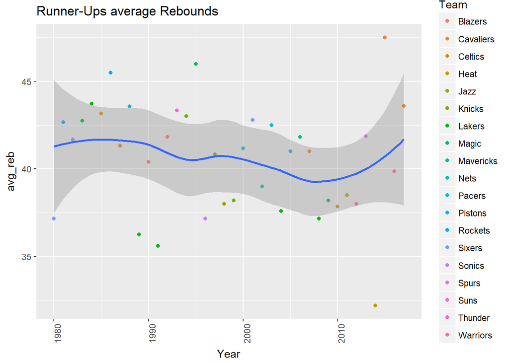

```r
#Plot for Runner-Ups average Rebounds every year in the data set
runner_ups %>%
   ggplot(mapping=aes(x=Year, y=avg_reb,label= Team)) +
  theme(axis.text.x = element_text(angle = 90, hjust = 1))+
  geom_point(aes(color= Team)) + geom_smooth() + ggtitle("Runner-Ups average Rebounds")
```

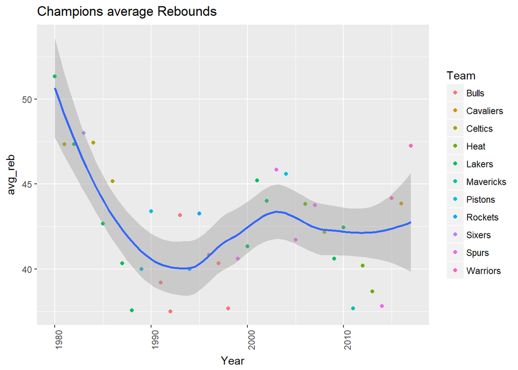

```r
#Plot for Champions average Rebounds every year in the data set
champions %>%
  ggplot(mapping=aes(x=Year, y=avg_reb,label= Team)) +
  theme(axis.text.x = element_text(angle = 90, hjust = 1))+
  geom_point(aes(color= Team)) + geom_smooth() + ggtitle("Champions average Rebounds")
```

The library being utilized here is ggplot2. We use the function ggplot(mapping(…)) to plot our dataset based on attributes x and y. For this graph we used the geom_point type of plot, but there are others like geom_bar,geom_line, geom_violin. We give it a title using ggtitle(). Other information on ggplot can be fount by typing in ?gglot2 in the console or you can check out this cheatsheet:http://www.rstudio.com/wp-content/uploads/2016/11/ggplot2-cheatsheet-2.1.pdf

```r
#Now we will combine both datasets into one
total <- rbind(runner_ups, champions)
```

[output not shown]

[output cut: 58 more lines]

[output not shown]

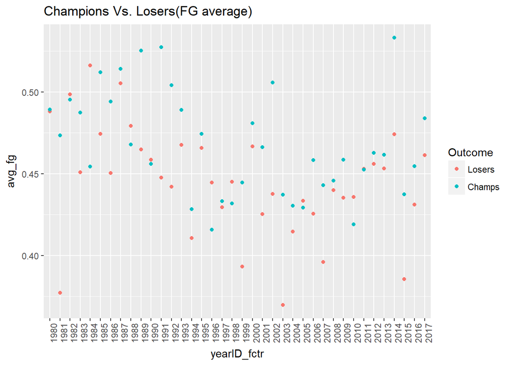

```r
#Plot showing FG averages for Champions vs Losers
total %>%
   mutate(yearID_fctr = as.factor(Year)) %>%
  group_by(yearID_fctr,Team) %>% ggplot(mapping=aes(x=yearID_fctr, y=avg_fg)) +
 theme(axis.text.x = element_text(angle = 90, hjust = 1)) +
 geom_point((aes(color= ifelse(Champs ==1,"red","blue")))) + ggtitle("Champions Vs. Losers(FG average)")+
  scale_colour_discrete(name  ="Outcome",labels=c("Losers","Champs"))
```

[output not shown]

[output cut: 61 more lines]

[output not shown]

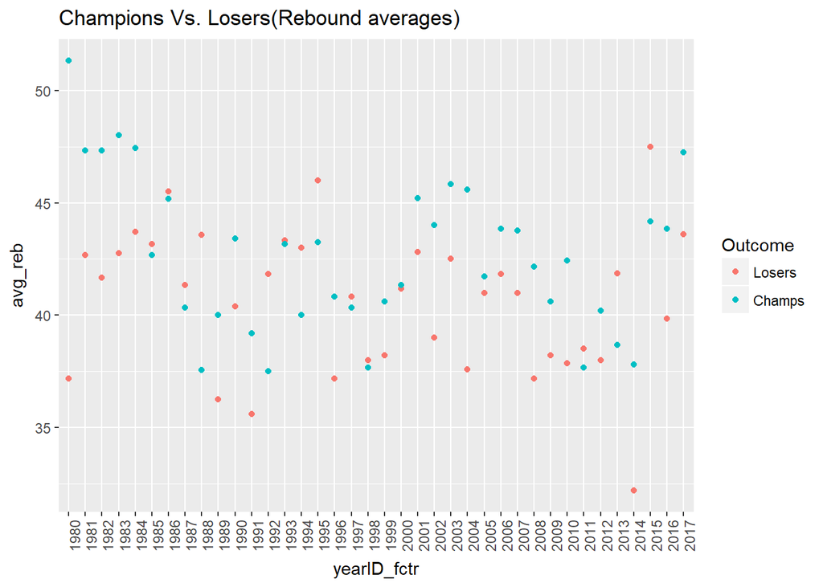

```r
#Plot showing Rebounding averages for Champions vs Losers
total %>%
   mutate(yearID_fctr = as.factor(Year)) %>%
  group_by(yearID_fctr,Team) %>% ggplot(mapping=aes(x=yearID_fctr, y=avg_reb)) +
 theme(axis.text.x = element_text(angle = 90, hjust = 1)) +
 geom_point((aes(color= ifelse(Champs ==1,"red","blue")))) + ggtitle("Champions Vs. Losers(Rebound averages)") +
  scale_colour_discrete(name  ="Outcome",labels=c("Losers","Champs"))
```

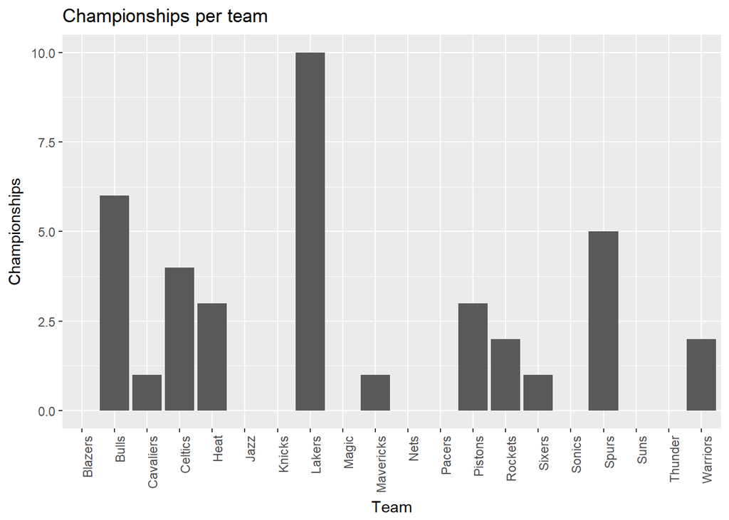

```r
#Plot showing how many Finals wins each team has(that has been to atleast one final)
total %>% group_by(Team) %>%
  summarise(Championships= sum(Champs), avg_fg=mean(avg_fg)) %>%
    ggplot(mapping=aes(x= Team, y= Championships))+
  theme(axis.text.x = element_text(angle = 90, hjust = 1))  +
  geom_bar(stat = "identity") + ggtitle("Championships per team") +
  xlab("Team") +
  scale_colour_discrete(name  ="Outcome",labels=c("Losers","Champs"))
```

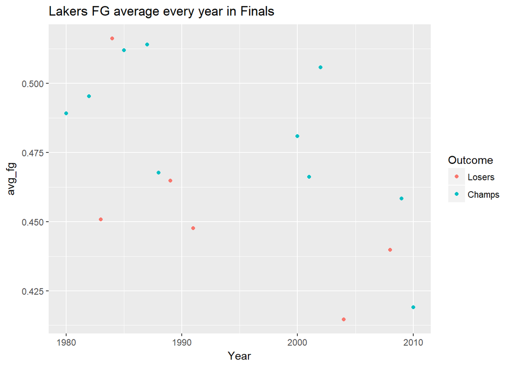

```r
#Plot showing Lakers FG Percentage when they won/lost Championships
Lakers_plot <- total %>% filter(Team== "Lakers")

Lakers_plot %>% ggplot(mapping=aes(x=Year, y=avg_fg)) + geom_point(aes(color= ifelse(Champs ==1,"red","blue"))) + ggtitle("Lakers FG average every year in Finals") +scale_colour_discrete(name  ="Outcome",labels=c("Losers","Champs"))
```

[figure not shown]

```r
#Plot showing Bulls FG Percentage when they won/lost Championships
Bulls_plot <- total %>% filter(Team== "Bulls")

Bulls_plot %>% ggplot(mapping=aes(x=Year, y=avg_fg)) + geom_point(aes(color= ifelse(Champs ==1,"red","blue"))) + ggtitle("Bulls FG average every year in Finals") +scale_colour_discrete(name  ="Outcome",labels=c("Losers","Champs"))
```

```r
salaries <- read_csv("NBASalaries1990to2016.csv")
salaries$Team <- gsub("^(\\w+)(\\w+)?\\s(\\w+)$","\\3",salaries$Team)
salaries$Year <- salaries$Season_Start
salaries
```

```
## # A tibble: 11,549 x 7
##    Team  Season_Start Season_End    Rk Player             Salary  Year
##    <chr>        <int>      <int> <int> <chr>               <int> <int>
##  1 Hawks         1990       1991     1 Moses Malone      2406000  1990
##  2 Hawks         1990       1991     2 Dominique Wilkins 2065000  1990
##  3 Hawks         1990       1991     3 Jon Koncak        1550000  1990
##  4 Hawks         1990       1991     4 Doc Rivers         895000  1990
##  5 Hawks         1990       1991     5 Rumeal Robinson    800000  1990
##  6 Hawks         1990       1991     6 Tim McCormick      775000  1990
##  7 Hawks         1990       1991     7 Kevin Willis       685000  1990
##  8 Hawks         1990       1991     8 Alexander Volkov   650000  1990
##  9 Hawks         1990       1991     9 John Battle        590000  1990
## 10 Hawks         1990       1991    10 Sidney Moncrief    510000  1990
## # ... with 11,539 more rows
```

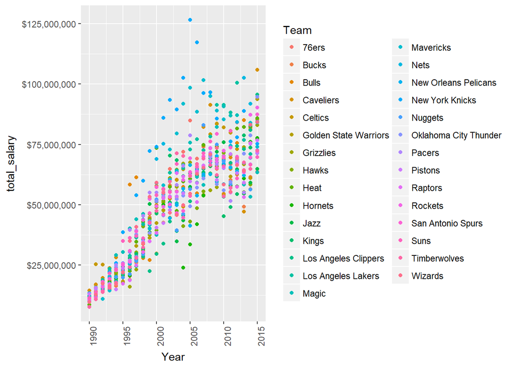

```r
salaries %>% group_by(Team,Year) %>% summarise(total_salary=sum(Salary)) %>%
  ggplot(mapping=aes(x=Year, y=total_salary))+
  scale_y_continuous(labels= scales::dollar)+
  theme(axis.text.x = element_text(angle = 90, hjust = 1)) + geom_point(aes(color= Team))
```

In this plot we see salaries increase as the years progress.

# Conclusion

In this tutorial, you should be very familiar with the basics of Data science. Learning functions from libraries such as dplyr, tidyverse,stringr, ggplot. Hopefully now you can go out on learn more about Data Science and explore some data!